# Bootstrap Confidence Interval on a mean

Bootstrapping is a method that relies on random sampling with replacement. This method allows us to build measures of accuracy or perform inference in situations where other methods prove difficult.

Let’s illustrate this via a simple example. Suppose we have 15 observations drawn from a random normal distribution.

```r
set.seed(35487)
n <- 15
x <- rnorm(n)
```

We can plot the density of this sample to confirm that it’s approximately normal.

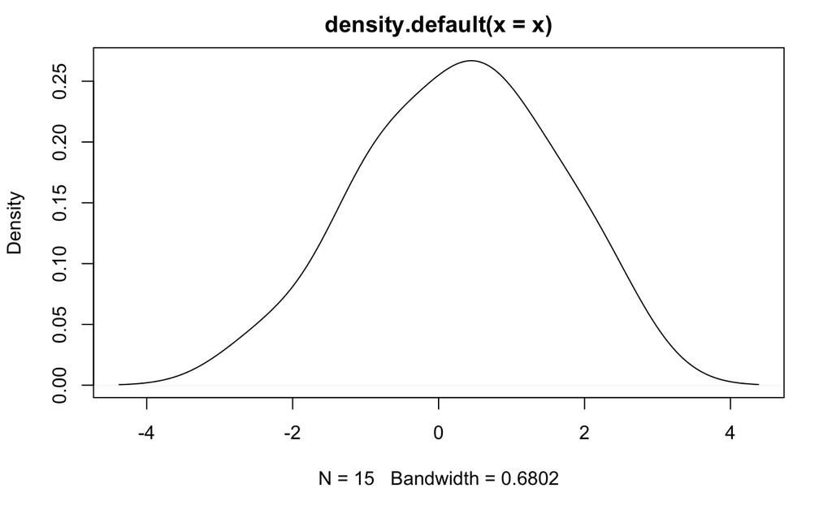

We can use a t-test to provide a confidence interval based on the normality assumption:

```r
t.test(x)
```

```
    One Sample t-test

data:  x
t = 0.79642, df = 14, p-value = 0.4391
alternative hypothesis: true mean is not equal to 0
95 percent confidence interval:
 -0.4522649  0.9865335
sample estimates:
mean of x
0.2671343
```

Now, we could also create a confidence interval by building a series of bootstrapped samples from our given sample of 15 observations. This involves sampling 15 observations from our original sample **with replacement** and calculating the mean value of these bootstrapped samples. It’s important to note that since we are sampling with replacement, there are $15^{15}$, or $4.3789389\times 10^{17}$ possible bootstrap samples. While we could *theoretically* include each of those samples, that would take an exceptional amount of time and compute power. Instead, we’ll once again rely on the central limit theorem and assume that if we provide a large enough collection of bootstrap samples, we will be ok.

```r
n_samples <- 10000
bootstrap_means <- replicate(n_samples, mean(sample(x, replace = TRUE)))
```

Now that we have these 10,000 sample means constructed from our original sample, we can explore the density and then use our collection of means to provide an estimated confidence interval.

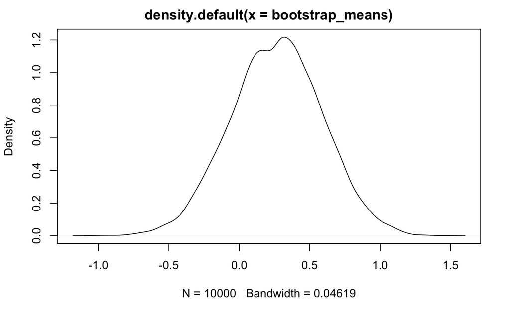

```r
ci <- quantile(bootstrap_means, probs = c(0.025, 0.975))
ci
```

```
      2.5%      97.5%
-0.3644780  0.8908767
```

Finally, we can visualize this confidence interval along with the density we previously plotted.

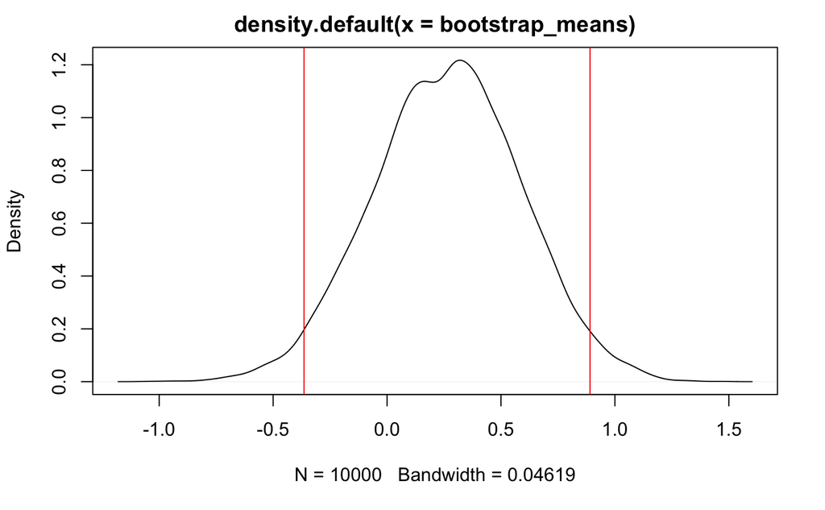

```r
plot(density(bootstrap_means))
abline(v = ci, col = "red")
```